## El presente estudio consiste en una aproximación biogeográfica de la especie *Brosimun alicastrum SW*, retomando su respectiva distribución en países de América Latina. Es considerada como una especie multipropósito, adquiere su funcionalidad a partir del uso y técnicas de aprovechamiento en distintas comunidades. Se pretende análisar la distribución actual del ojoche y aproximarse al aprovechamiento que genera esta especie a nivel a las comunidades y soberanía alimentaria.

(Brosimum alicastrum)

[figure not shown]

# Metodología

## Distribución geográfica

```python
pip install tabulate
```

### Aprovechamiento del Ojoche

| Aprovechamiento | Estructura |
| --- | --- |
| 1. Follaje. 2. Medicina. 3. Alimentos. | Hojas, semillas. Semillas, corteza,latex. Agua. |

## Variedades de ojoche

```python
# Import the tabulate module
from tabulate import tabulate

# Sample data: list of lists
data = [
    ["Reino", "Plantae"],
    ["Filo", "Tracheophyta"],
    ["Clase", "Magnoliopsida"]
]

# Creating a table with headers and a grid format
table = tabulate(
    data,
    headers=["Clasificación", "NOmbre"],
    tablefmt="grid"
)

print(table)
```

```
+-----------------+---------------+
| Clasificación   | NOmbre        |
+=================+===============+
| Reino           | Plantae       |
+-----------------+---------------+
| Filo            | Tracheophyta  |
+-----------------+---------------+
| Clase           | Magnoliopsida |
+-----------------+---------------+
```

```python
import geopandas as gpd
```

```python
# Carga de pandas con el alias pd
import pandas as pd

# Carga de folium
import folium

# Carga de matplotlib
import matplotlib.pyplot as plt
```

```python
# Biblioteca requerida para mapas interactivos
!pip install mapclassify --quiet

import mapclassify
```

```python
# Montaje de Google Drive en Colab
from google.colab import drive
drive.mount('/content/drive')
```

```python
# Carga de un archivo CSV desde Google Drive
ojoche = pd.read_csv(
    "/content/drive/MyDrive/Colab Notebooks/ojoche.csv",
    sep="\t"
)
# Despliegue de los últimos registros
ojoche.tail(10)
```

|  | gbifID | datasetKey | occurrenceID | kingdom | phylum | class | order | family | genus | species | ... | identifiedBy | dateIdentified | license | rightsHolder | recordedBy | typeStatus | establishmentMeans | lastInterpreted | mediaType | issue |
| --- | --- | --- | --- | --- | --- | --- | --- | --- | --- | --- | --- | --- | --- | --- | --- | --- | --- | --- | --- | --- | --- |
| 14197 | 1038454392 | 99b1c33f-113b-4477-8075-a9bbe5df0246 | IAvH:BICUB:MAGNOLIOPHYTA:OBSERVACIONHUMANA:I2D... | Plantae | Tracheophyta | Magnoliopsida | Rosales | Moraceae | Brosimum | Brosimum alicastrum | ... | NaN | NaN | CC_BY_NC_4_0 | UTP | Dorian Ruiz Penagos | NaN | NaN | 2025-02-06T18:17:13.282Z | NaN | GEODETIC_DATUM_ASSUMED_WGS84;CONTINENT_DERIVED... |
| 14198 | 1038454387 | 99b1c33f-113b-4477-8075-a9bbe5df0246 | IAvH:BICUB:MAGNOLIOPHYTA:OBSERVACIONHUMANA:I2D... | Plantae | Tracheophyta | Magnoliopsida | Rosales | Moraceae | Brosimum | Brosimum alicastrum | ... | NaN | NaN | CC_BY_NC_4_0 | UTP | Dorian Ruiz Penagos | NaN | NaN | 2025-02-06T18:17:13.309Z | NaN | GEODETIC_DATUM_ASSUMED_WGS84;CONTINENT_DERIVED... |
| 14199 | 1038454380 | 99b1c33f-113b-4477-8075-a9bbe5df0246 | IAvH:BICUB:MAGNOLIOPHYTA:OBSERVACIONHUMANA:I2D... | Plantae | Tracheophyta | Magnoliopsida | Rosales | Moraceae | Brosimum | Brosimum alicastrum | ... | NaN | NaN | CC_BY_NC_4_0 | UTP | Dorian Ruiz Penagos | NaN | NaN | 2025-02-06T18:17:13.280Z | NaN | GEODETIC_DATUM_ASSUMED_WGS84;CONTINENT_DERIVED... |
| 14200 | 1038454309 | 99b1c33f-113b-4477-8075-a9bbe5df0246 | IAvH:BICUB:MAGNOLIOPHYTA:OBSERVACIONHUMANA:I2D... | Plantae | Tracheophyta | Magnoliopsida | Rosales | Moraceae | Brosimum | Brosimum alicastrum | ... | NaN | NaN | CC_BY_NC_4_0 | UTP | Dorian Ruiz Penagos | NaN | NaN | 2025-02-06T18:17:13.161Z | NaN | GEODETIC_DATUM_ASSUMED_WGS84;CONTINENT_DERIVED... |
| 14201 | 1038454280 | 99b1c33f-113b-4477-8075-a9bbe5df0246 | IAvH:BICUB:MAGNOLIOPHYTA:OBSERVACIONHUMANA:I2D... | Plantae | Tracheophyta | Magnoliopsida | Rosales | Moraceae | Brosimum | Brosimum alicastrum | ... | NaN | NaN | CC_BY_NC_4_0 | UTP | Dorian Ruiz Penagos | NaN | NaN | 2025-02-06T18:17:13.147Z | NaN | GEODETIC_DATUM_ASSUMED_WGS84;CONTINENT_DERIVED... |
| 14202 | 1038454244 | 99b1c33f-113b-4477-8075-a9bbe5df0246 | IAvH:BICUB:MAGNOLIOPHYTA:OBSERVACIONHUMANA:I2D... | Plantae | Tracheophyta | Magnoliopsida | Rosales | Moraceae | Brosimum | Brosimum alicastrum | ... | NaN | NaN | CC_BY_NC_4_0 | UTP | Dorian Ruiz Penagos | NaN | NaN | 2025-02-06T18:17:13.214Z | NaN | GEODETIC_DATUM_ASSUMED_WGS84;CONTINENT_DERIVED... |
| 14203 | 1038454193 | 99b1c33f-113b-4477-8075-a9bbe5df0246 | IAvH:BICUB:MAGNOLIOPHYTA:OBSERVACIONHUMANA:I2D... | Plantae | Tracheophyta | Magnoliopsida | Rosales | Moraceae | Brosimum | Brosimum alicastrum | ... | NaN | NaN | CC_BY_NC_4_0 | UTP | Dorian Ruiz Penagos | NaN | NaN | 2025-02-06T18:17:13.204Z | NaN | GEODETIC_DATUM_ASSUMED_WGS84;CONTINENT_DERIVED... |
| 14204 | 1038454180 | 99b1c33f-113b-4477-8075-a9bbe5df0246 | IAvH:BICUB:MAGNOLIOPHYTA:OBSERVACIONHUMANA:I2D... | Plantae | Tracheophyta | Magnoliopsida | Rosales | Moraceae | Brosimum | Brosimum alicastrum | ... | NaN | NaN | CC_BY_NC_4_0 | UTP | Dorian Ruiz Penagos | NaN | NaN | 2025-02-06T18:17:13.206Z | NaN | GEODETIC_DATUM_ASSUMED_WGS84;CONTINENT_DERIVED... |
| 14205 | 1038454149 | 99b1c33f-113b-4477-8075-a9bbe5df0246 | IAvH:BICUB:MAGNOLIOPHYTA:ESPECIMENPRESERVADO:I... | Plantae | Tracheophyta | Magnoliopsida | Rosales | Moraceae | Brosimum | Brosimum alicastrum | ... | NaN | NaN | CC_BY_NC_4_0 | UTP | Dorian Ruiz Penagos | NaN | NaN | 2025-02-06T18:17:13.165Z | NaN | GEODETIC_DATUM_ASSUMED_WGS84;CONTINENT_DERIVED... |
| 14206 | 1030510718 | bd910e78-7a69-44ac-9450-65bf41329604 | IAvH:BICUB:TOLIMA:PLANTAE:OBSERVACIONHUMANA:I2... | Plantae | Tracheophyta | Magnoliopsida | Rosales | Moraceae | Brosimum | Brosimum alicastrum | ... | NaN | NaN | CC_BY_NC_4_0 | UD | Roy Gonzalez-M.;Jhon Nieto;Daniel García | NaN | NaN | 2025-02-06T18:26:18.704Z | NaN | COORDINATE_ROUNDED;GEODETIC_DATUM_ASSUMED_WGS8... |

10 rows × 50 columns

```python
# Crear un GeoDataFrame a partir del DataFrame
ojoche= gpd.GeoDataFrame(
    ojoche,
    geometry=gpd.points_from_xy(ojoche.decimalLongitude, ojoche.decimalLatitude),
    crs='EPSG:4326'
)
```

```python
# Información general sobre un dataframe
ojoche.info()
```

```
<class 'geopandas.geodataframe.GeoDataFrame'>
RangeIndex: 14207 entries, 0 to 14206
Data columns (total 51 columns):
 #   Column                            Non-Null Count  Dtype
---  ------                            --------------  -----
 0   gbifID                            14207 non-null  int64
 1   datasetKey                        14207 non-null  object
 2   occurrenceID                      14079 non-null  object
 3   kingdom                           14207 non-null  object
 4   phylum                            14207 non-null  object
 5   class                             14207 non-null  object
 6   order                             14207 non-null  object
 7   family                            14207 non-null  object
 8   genus                             14207 non-null  object
 9   species                           14207 non-null  object
```

[output cut: 43 more lines]

[output not shown]

Distributions

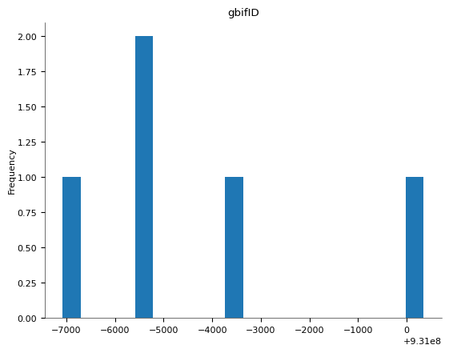

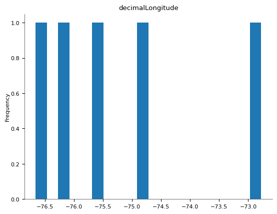

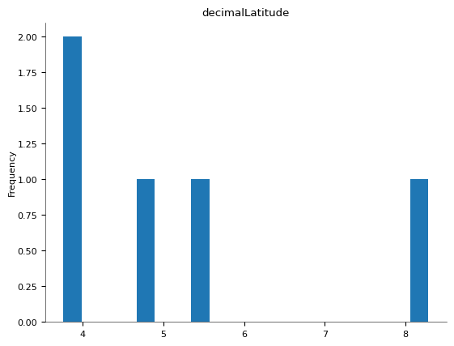

Categorical distributions

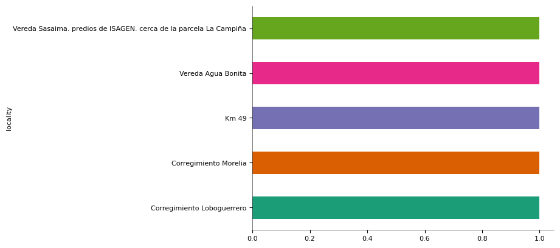

2-d distributions

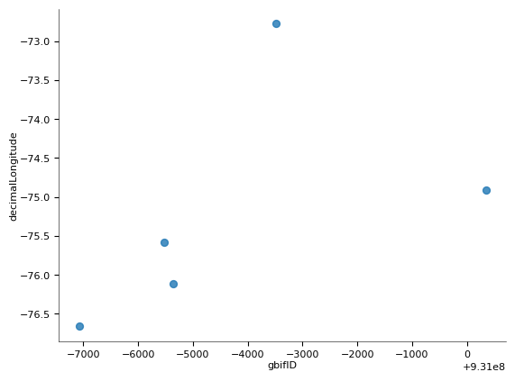

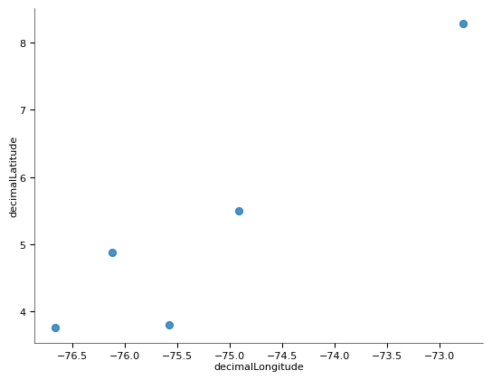

Values

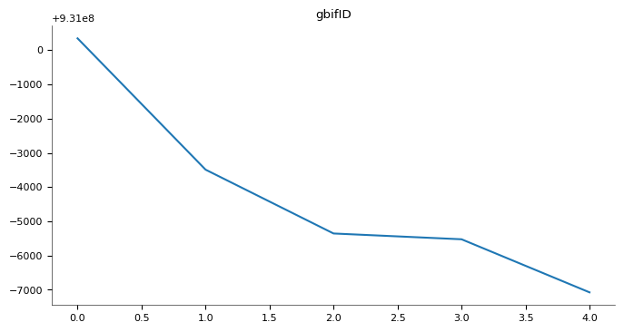

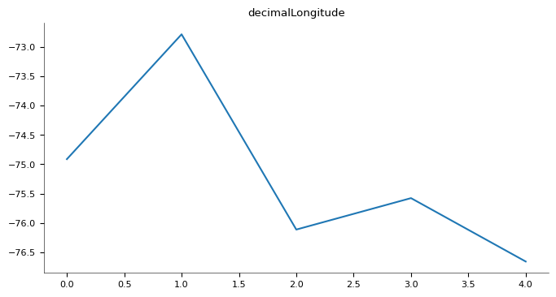

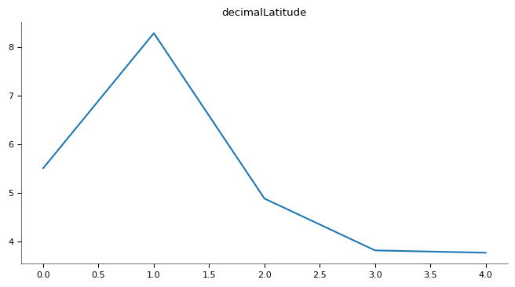

Faceted distributions

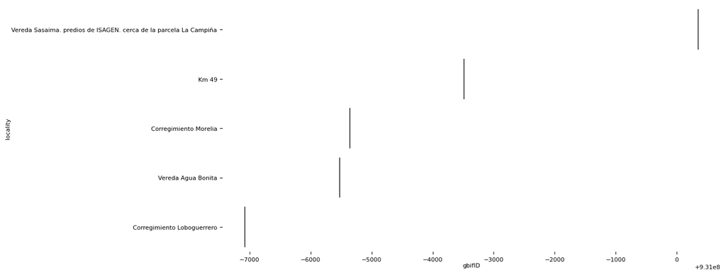

[figure not shown]

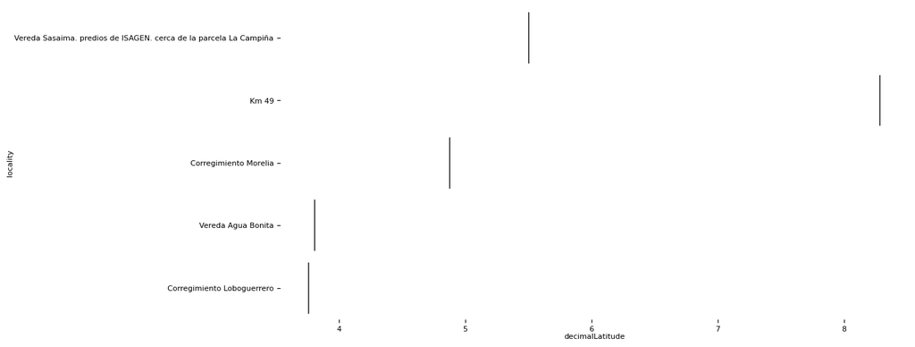

```python
# Crear un GeoDataFrame a partir del DataFrame
ojoche= gpd.GeoDataFrame(
    ojoche,
    geometry=gpd.points_from_xy(ojoche.decimalLongitude, ojoche.decimalLatitude),
    crs='EPSG:4326'
)

# Mostrar los primeros registros del GeoDataFrame,
# incluyendo la columna de geometría
ojoche[['gbifID', 'species', 'decimalLongitude', 'decimalLatitude', 'countryCode', 'locality']].head()
```

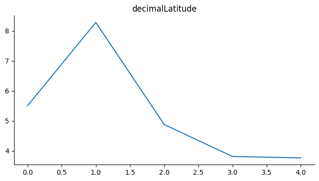

```python
from matplotlib import pyplot as plt
_df_64['decimalLatitude'].plot(kind='line', figsize=(8, 4), title='decimalLatitude')
plt.gca().spines[['top', 'right']].set_visible(False)
```

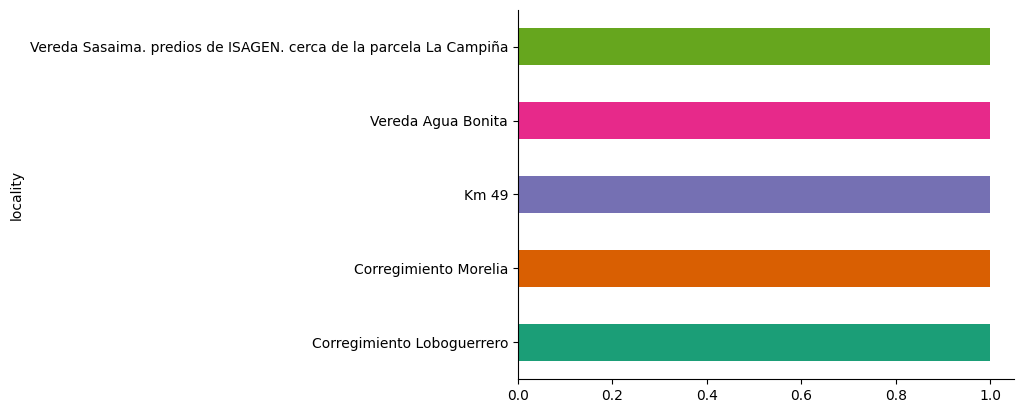

```python
from matplotlib import pyplot as plt
import seaborn as sns
_df_59.groupby('locality').size().plot(kind='barh', color=sns.palettes.mpl_palette('Dark2'))
plt.gca().spines[['top', 'right',]].set_visible(False)
```

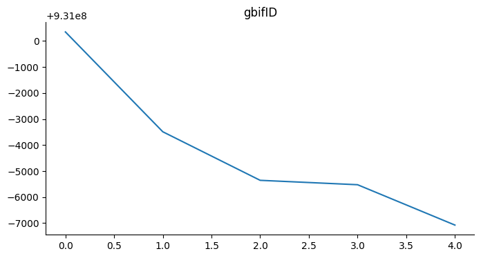

```python
from matplotlib import pyplot as plt
_df_26['gbifID'].plot(kind='line', figsize=(8, 4), title='gbifID')
plt.gca().spines[['top', 'right']].set_visible(False)
```

```python
# Carga del módulo pyplot de matplotlib con el alias plt
import matplotlib.pyplot as plt
```

## Se crea un mapa estático simple para visualizar la distribución geográfica del árbol de ojoche (Brosimum alicastrum), también llamado "Ramón" o "ramón maya". Utiliza los datos almacenados en una variable llamada ojoche.

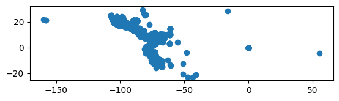

```python
# Mapa estático de registros de ojoche
ojoche.plot()
```

```python
!pip install cartopy
import cartopy
```

[output not shown]

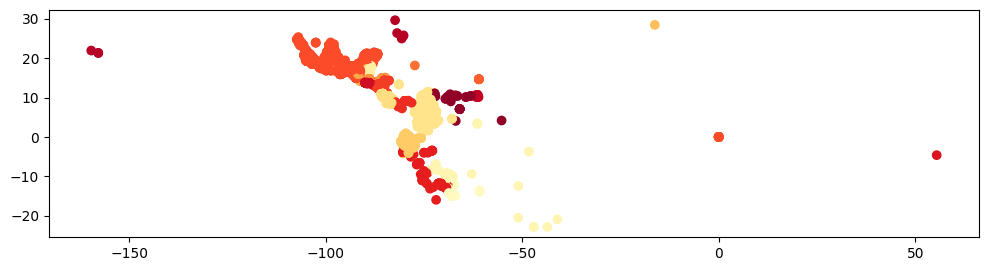

```python
# Mapa de coropletas
new_var = ojoche.plot(
    column='countryCode',
    cmap='YlOrRd', # https://matplotlib.org/stable/gallery/color/colormap_reference.html
    legend=True,
    legend_kwds={
        'label': "Población estimada",
        'orientation': "horizontal"
    },
    figsize=(12, 8)
)
```

```python
# Carga de plotly.express con el alias px
import plotly.express as px

# Carga de pandas
import pandas as pd
```

```python
# Carga de pandas
import pandas as pd
```

```python
# Borrado de filas que no tengan año
df_anio_no_nulo = ojoche.dropna(subset=['year'])

# Filtrado de los años entre 2005 y 2025
df_filtrado = df_anio_no_nulo[(df_anio_no_nulo['year'] >= 2005) & (df_anio_no_nulo['year'] <= 2015)]

# Conteo de registros por año
registros_por_anio = df_filtrado.groupby('year')['gbifID'].count().reset_index()

# Creación del gráfico de barras
fig = px.bar(
    registros_por_anio,
    x='year',
    y='gbifID',
    title='Cantidad de registros (años 2005 - 2015)'
)

# Personalización
fig.update_layout(
    xaxis_title='Año',
    yaxis_title='Cantidad de registros',
    width=1000,    # Ancho de la figura
    height=600     # Alto de la figura
)
```

[interactive chart not shown]

(Brosimum alicastrum)

[figure not shown]

```python
# Borrado de filas que no tengan año
df_anio_no_nulo = ojoche.dropna(subset=['year'])

# Filtrado de los años entre 2015 y 2025
df_filtrado = df_anio_no_nulo[(df_anio_no_nulo['year'] >= 2015) & (df_anio_no_nulo['year'] <= 2025)]

# Conteo de registros por año
registros_por_anio = df_filtrado.groupby('year')['locality'].count().reset_index()

# Creación del gráfico de barras
fig = px.bar(
    registros_por_anio,
    x='year',
    y='locality',
    title='Cantidad de registros (años 20020 - 2025)'
)

# Personalización
fig.update_layout(
    xaxis_title='Año',
    yaxis_title='Cantidad de registros',
    width=800,    # Ancho de la figura
    height=600     # Alto de la figura
)
```

[interactive chart not shown]

```python
# Instalación de rasterio
!pip install rasterio --quiet
```

```
   ━━━━━━━━━━━━━━━━━━━━━━━━━━━━━━━━━━━━━━━━ 22.2/22.2 MB 71.2 MB/s eta 0:00:00
```

```python
# Carga de rasterio
import rasterio

# Carga de rasterio.plot (para graficar datos raster)
import rasterio.plot

# Carga de numpy (para álgebra lineal)
import numpy as np

# Carga de matplotlib.pyplot
import matplotlib.pyplot as plt
```

```python
import rasterio
import rasterio.plot
import geopandas as gpd
import numpy as np
import matplotlib.pyplot as plt
```

## El ojoche se extiende en medio del tropico, principalmente por todo centroamérica, en bosques, bajo temperaturas más altas.

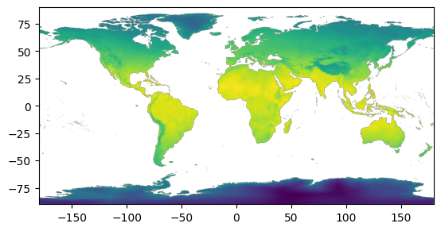

```python
# Mapa de temperatura media anual
rasterio.plot.show(temperatura_media_anual)
```

# Referencias bibliográficas

## Roque, A. Orantes, C. 2012. Aprovechamiento del árbol nativo Brosimum alicastrum Swartz (Moraceae) en la Selva Zoque Chiapas, México. https://repositorio.unicach.mx/handle/20.500.12753/1723

## Ramírez, S. 2017. EL RAMÓN (Brosimum alicastrum Swartz) UNA ALTERNATIVA PARA LA SEGURIDAD ALIMENTARIA EN MÉXICO. Vol. 10 Núm. 1 (2017): ENERO.https://www.revista-agroproductividad.org/index.php/agroproductividad/article/view/943